# STAT 341: Tutorial 3 – Pokemon Analysis (Part 2)

Friday January 24, 2020

Let’s read-in the `pokemon` data and get some practice with power transformations and implicitly defined attributes.

```r
poke <- read.csv("/Users/nstevens/Dropbox/Teaching/STAT_341/Tutorials/Tutorial 3/pokemon.csv",
    header = TRUE)
```

## Task 1:

Create a $1 \times 3$ plot which includes:

- A histogram of `speed`
- A histogram of `weight_kg`
- A scatterplot of `speed` vs. `weight_kg`

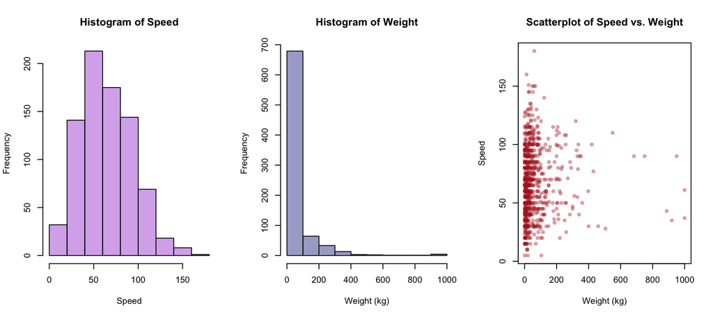

```r
par(mfrow = c(1, 3))
hist(x = poke$speed, main = "Histogram of Speed", xlab = "Speed", col = adjustcolor(col = "darkorchid",
    alpha = 0.4))
hist(x = poke$weight_kg, main = "Histogram of Weight", xlab = "Weight (kg)",
    col = adjustcolor(col = "navyblue", alpha = 0.4))
plot(x = poke$weight_kg, y = poke$speed, main = "Scatterplot of Speed vs. Weight",
    xlab = "Weight (kg)", ylab = "Speed", pch = 16, col = adjustcolor(col = "firebrick",
        alpha = 0.4))
```

## Task 2:

Find a range of $\alpha$ values that would help to “symmetrize” the `speed` distribution. Plot the histogram of $T_{\alpha}(\texttt{speed})$ using the value of $\alpha$ that seems most appropriate.

```r
powerfun <- function(x, alpha) {
    if (sum(x <= 0) > 0)
        stop("x must be positive")
    if (alpha == 0)
        log(x) else if (alpha > 0) {
        x^alpha
    } else -x^alpha
}
```

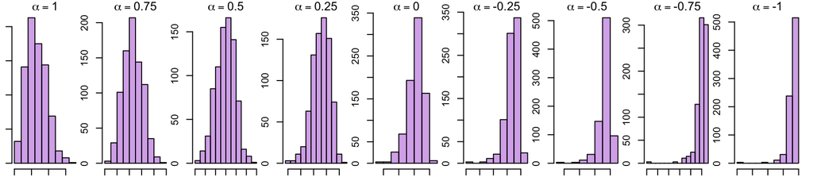

```r
par(mfrow = c(1, 9), mar = c(1, 1, 1, 1))
alpha <- seq(from = 1, to = -1, by = -0.25)
for (i in 1:length(alpha)) {
    hist(x = powerfun(x = poke$speed, alpha = alpha[i]), main = bquote(alpha ==
        .(alpha[i])), xlab = "", col = adjustcolor(col = "darkorchid",
        alpha = 0.4))
}
```

Based on the figure above, $\alpha = 0.5$ seems to do the best job. Here is a plot of the square-root-transformed `speed` data:

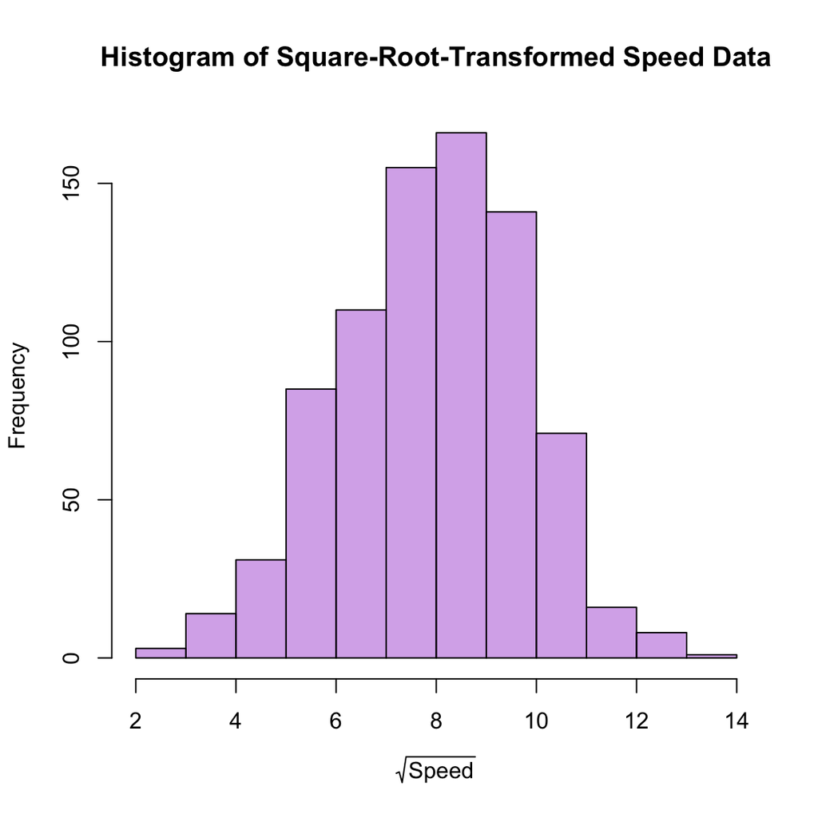

```r
par(mfrow = c(1, 1))
hist(x = powerfun(x = poke$speed, alpha = 0.5), main = "Histogram of Square-Root-Transformed Speed Data",
    xlab = expression(sqrt(Speed)), col = adjustcolor(col = "darkorchid",
        alpha = 0.4))
```

## Task 3:

Find a range of $\alpha$ values that would help to “symmetrize” the `weight` distribution. Plot the histogram of $T_{\alpha}(\texttt{weight})$ using the value of $\alpha$ that seems most appropriate.

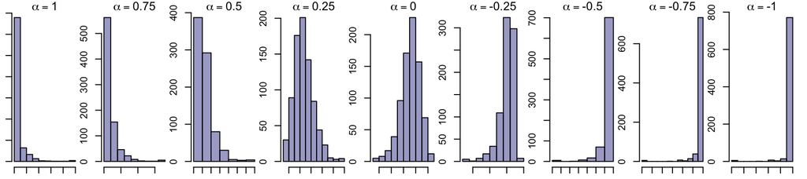

```r
par(mfrow = c(1, 9), mar = c(1, 1, 1, 1))
alpha <- seq(from = 1, to = -1, by = -0.25)
for (i in 1:length(alpha)) {
    hist(x = powerfun(x = poke$weight_kg, alpha = alpha[i]), main = bquote(alpha ==
        .(alpha[i])), xlab = "", col = adjustcolor(col = "navyblue", alpha = 0.4))
}
```

Based on the figure above, $\alpha \in [0,0.25]$ looks good. Let’s refine our search:

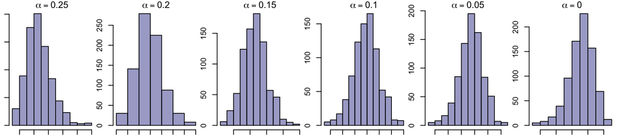

```r
par(mfrow = c(1, 6), mar = c(1, 1, 1, 1))
alpha <- seq(from = 0.25, to = 0, by = -0.05)
for (i in 1:length(alpha)) {
    hist(x = powerfun(x = poke$weight_kg, alpha = alpha[i]), main = bquote(alpha ==
        .(alpha[i])), xlab = "", col = adjustcolor(col = "navyblue", alpha = 0.4))
}
```

Based on the plots above, choosing $\alpha = 0.1$ seems like it should work well. Here is a plot of this power-transformed `weight` data:

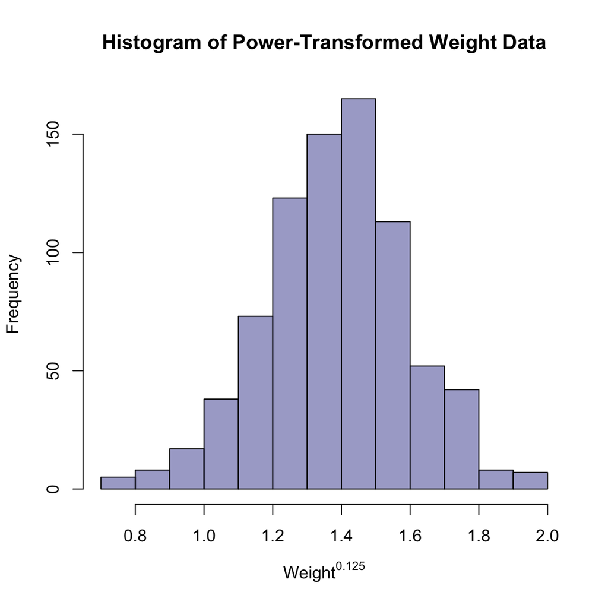

```r
par(mfrow = c(1, 1))
hist(x = powerfun(x = poke$weight_kg, alpha = 0.1), main = "Histogram of Power-Transformed Weight Data",
    xlab = bquote(Weight^0.125), col = adjustcolor(col = "navyblue", alpha = 0.4))
```

## Task 4:

Cast the ‘optimal power transformation’ problem in the univariate setting as an implicitly defined attribute problem and determine the optimal $\alpha$ values for both the `speed` and `weight` data. Construct histograms of these optimally-power-transformed variates.

Let $\alpha$ be the attribute of interest, and let $t_u = T_{\alpha}(y_u)$ be the power-transformed observation for unit $u$. Let us also define the objective function to be minimized as the absolute value of Pearson’s moment coefficient of skewness for the transformed data:
$$\rho(\alpha;\mathcal{P}) = \left|\frac{\frac{1}{N}\sum_{u \in \mathcal{P}}\left(t_u-\bar{t}\right)^3}{[SD(t)]^3}\right|$$

Thus the problem of finding the optimal $\alpha$ reduces to the following optimization problem:
$$\widehat{\alpha} = \operatorname*{arg min}_{\alpha \in \mathbb{R}}\rho(\alpha;\mathcal{P})$$

In `R` let’s define $\rho(\alpha;\mathcal{P})$ and then use the `nlminb` function to minimize it.

```r
rho_skew <- function(theta, y) {
    t <- powerfun(y, alpha = theta)
    skew <- mean((t - mean(t))^3)/sd(t)^3
    return(abs(skew))
}
```

Let’s find the optimal $\alpha$ for the `speed` data and plot the resulting histogram:

```r
min1 <- nlminb(start = 1, objective = rho_skew, y = poke$speed)
print(min1)
```

```
## $par
## [1] 0.6104124
##
## $objective
## [1] 1.960757e-10
##
## $convergence
## [1] 0
##
## $iterations
## [1] 11
##
## $evaluations
## function gradient
##       26       11
##
## $message
## [1] "X-convergence (3)"
```

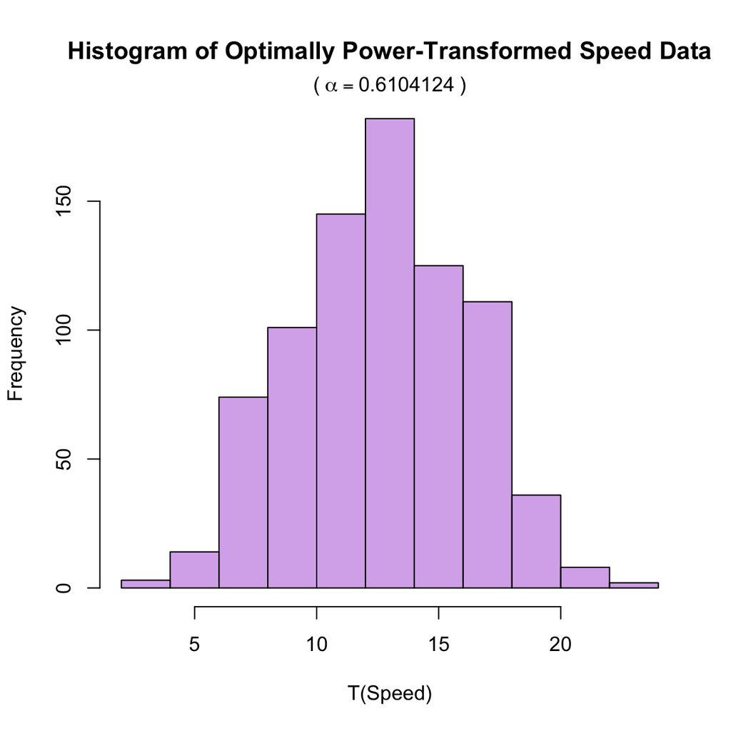

```r
hist(x = powerfun(x = poke$speed, alpha = min1$par), main = "Histogram of Optimally Power-Transformed Speed Data",
    xlab = "T(Speed)", col = adjustcolor(col = "darkorchid", alpha = 0.4))
mtext(text = bquote("(" ~ alpha == .(min1$par) ~ ")"), side = 3)
```

Let’s find the optimal $\alpha$ for the `weight` data and plot the resulting histogram:

```r
min2 <- nlminb(start = 1, objective = rho_skew, y = poke$weight_kg)
print(min2)
```

```
## $par
## [1] 0.1047096
##
## $objective
## [1] 1.856518e-09
##
## $convergence
## [1] 0
##
## $iterations
## [1] 17
##
## $evaluations
## function gradient
##       26       18
##
## $message
## [1] "X-convergence (3)"
```

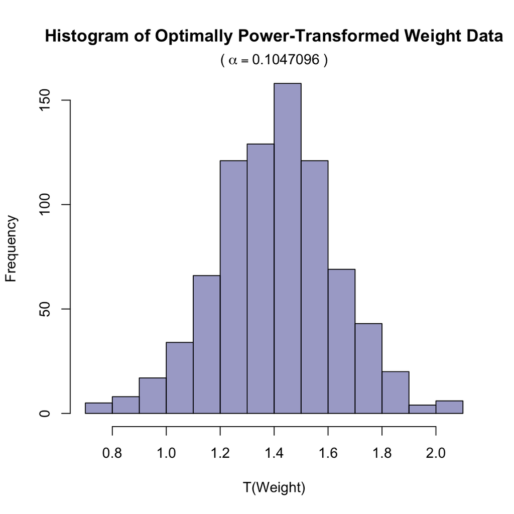

```r
hist(x = powerfun(x = poke$weight_kg, alpha = min2$par), main = "Histogram of Optimally Power-Transformed Weight Data",
    xlab = "T(Weight)", col = adjustcolor(col = "navyblue", alpha = 0.4))
mtext(text = bquote("(" ~ alpha == .(min2$par) ~ ")"), side = 3)
```

Notice that in both cases the “optimal $\alpha$” was not far from the values we determined using Bump Rule #1. In general, although we can always find an optimal power transformation algorithmically (like we did above), the ladder heuristc tends to work pretty well.

## Task 5:

Find a range of $\alpha_x$ and $\alpha_y$ values that would help to “linearize” the relationship between $T_{\alpha_y}(\texttt{speed})$ and $T_{\alpha_x}(\texttt{weight})$. Plot the scatterplot of $T_{\alpha_y}(\texttt{speed})$ vs. $T_{\alpha_x}(\texttt{weight})$ using the values of $\alpha_y$ and $\alpha_x$ that seem most appropriate.

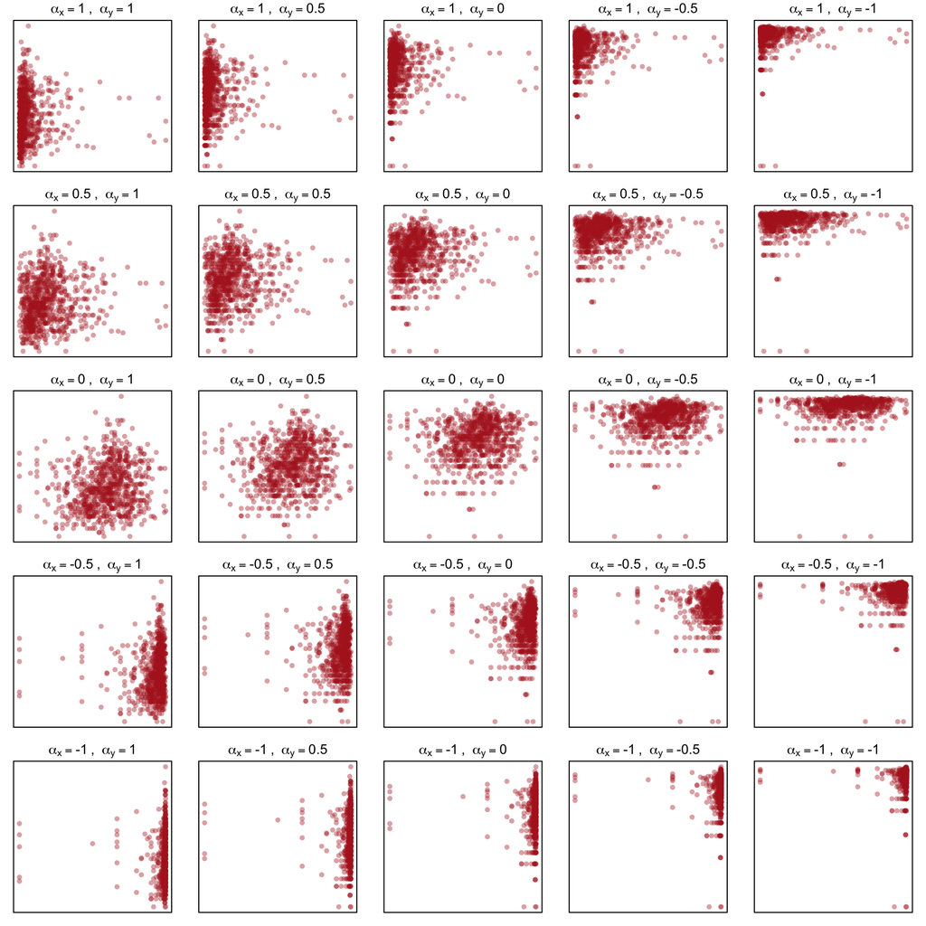

```r
alpha_x <- seq(from = 1, to = -1, length.out = 5)
alpha_y <- seq(from = 1, to = -1, length.out = 5)

corMat <- matrix(0, nrow = length(alpha_x), ncol = length(alpha_y))

par(mfrow = c(length(alpha_x), length(alpha_y)), mar = c(1, 1, 1.5, 1))
for (i in 1:length(alpha_x)) {
    for (j in 1:length(alpha_y)) {
        plot(x = powerfun(poke$weight_kg, alpha = alpha_x[i]), y = powerfun(poke$speed,
            alpha = alpha_y[j]), main = bquote(alpha[x] == .(alpha_x[i]) ~
            ", " ~ alpha[y] == .(alpha_y[j])), xlab = "", ylab = "", xaxt = "n",
            yaxt = "n", pch = 16, col = adjustcolor(col = "firebrick",
                alpha = 0.4))
        corMat[i, j] <- cor(powerfun(poke$weight_kg, alpha = alpha_x[i]),
            powerfun(poke$speed, alpha = alpha_y[j]))
    }
}
```

```r
print(corMat)
```

```
##              [,1]         [,2]        [,3]        [,4]        [,5]
## [1,]  0.045350075  0.049146552  0.05232798 0.053318490 0.048988964
## [2,]  0.105155308  0.108691033  0.10940878 0.103858343 0.087625031
## [3,]  0.137581854  0.141344203  0.14163987 0.133730941 0.112092608
## [4,]  0.062635621  0.066392912  0.06973781 0.069870715 0.062781331
## [5,] -0.007438598 -0.005643728 -0.00263538 0.001083586 0.004323217
```

The plot and matrix of correlations above suggest that $\alpha_x=0$ and $\alpha_y=0$ provide power transformations such that the relationship between $T_{\alpha_y}(\texttt{speed})$ and $T_{\alpha_x}(\texttt{weight})$ is *most linear*. Further refinement of the $\alpha$’s is definitely possible, but a log-transformation is nice and easy to interpret so let’s go ahead with it:

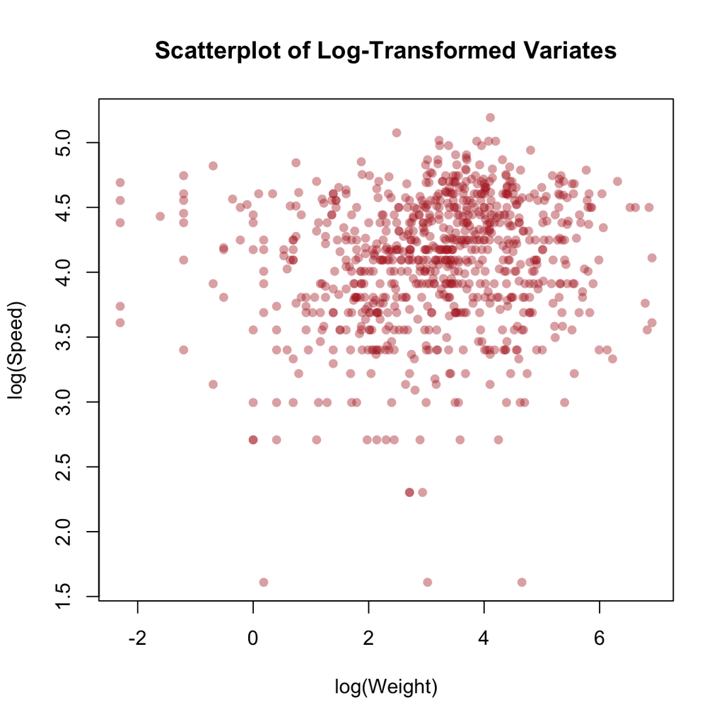

```r
par(mfrow = c(1, 1))
plot(x = powerfun(poke$weight_kg, alpha = 0), y = powerfun(poke$speed,
    alpha = 0), main = "Scatterplot of Log-Transformed Variates", xlab = "log(Weight)",
    ylab = "log(Speed)", pch = 16, col = adjustcolor(col = "firebrick",
        alpha = 0.4))
```

## Task 6:

Cast the ‘optimal power transformation’ problem in the bivariate setting as an implicitly defined attribute problem and determine the optimal $\boldsymbol\alpha$ value to “straighten” the scatterplot of `speed` versus `weight`. Construct a scatterplot using the optimally-power-transformed variates.

Let $\boldsymbol\alpha = (\alpha_x, \alpha_y)$ be the attribute of interest, and let $t_u = T_{\alpha_y}(y_u)$ and $v_u = T_{\alpha_x}(x_u)$. Let us also define the objective function to be minimized as the negative of the absolute value of the correlation coefficient between the transformed variates (since we actually want to maximize this):
$$\rho(\boldsymbol\alpha;\mathcal{P}) = -\left|\frac{\sum_{u \in \mathcal{P}}(v_u-\bar{v})(t_u-\bar{t})}{\sqrt{\sum_{u \in \mathcal{P}}(v_u-\bar{v})^2}\sqrt{\sum_{u \in \mathcal{P}}(t_u-\bar{t})^2}}\right|$$

Thus the problem of finding the optimal $\boldsymbol\alpha$ reduces to the following optimization problem:
$$\widehat{\boldsymbol\alpha} = \operatorname*{arg min}_{\boldsymbol\alpha \in \mathbb{R}^2}\rho(\boldsymbol\alpha;\mathcal{P})$$

In `R` let’s define $\rho(\boldsymbol\alpha;\mathcal{P})$ and then use the `nlminb` function to minimize it.

```r
rho_cor <- function(alpha, x, y) {
    alphax <- alpha[1]
    alphay <- alpha[2]
    return(-abs(cor(x = powerfun(x, alpha = alphax), y = powerfun(y, alpha = alphay))))
}
```

Let’s find the optimal $\boldsymbol\alpha$ for the scatterplot of `speed` versus `weight` and plot the resulting optimally transformed data:

```r
min3 <- nlminb(start = c(1, 1), objective = rho_cor, x = poke$weight_kg,
    y = poke$speed)
print(min3)
```

```
## $par
## [1] 0.06378426 0.22637566
##
## $objective
## [1] -0.1431949
##
## $convergence
## [1] 0
##
## $iterations
## [1] 14
##
## $evaluations
## function gradient
##       17       36
##
## $message
## [1] "relative convergence (4)"
```

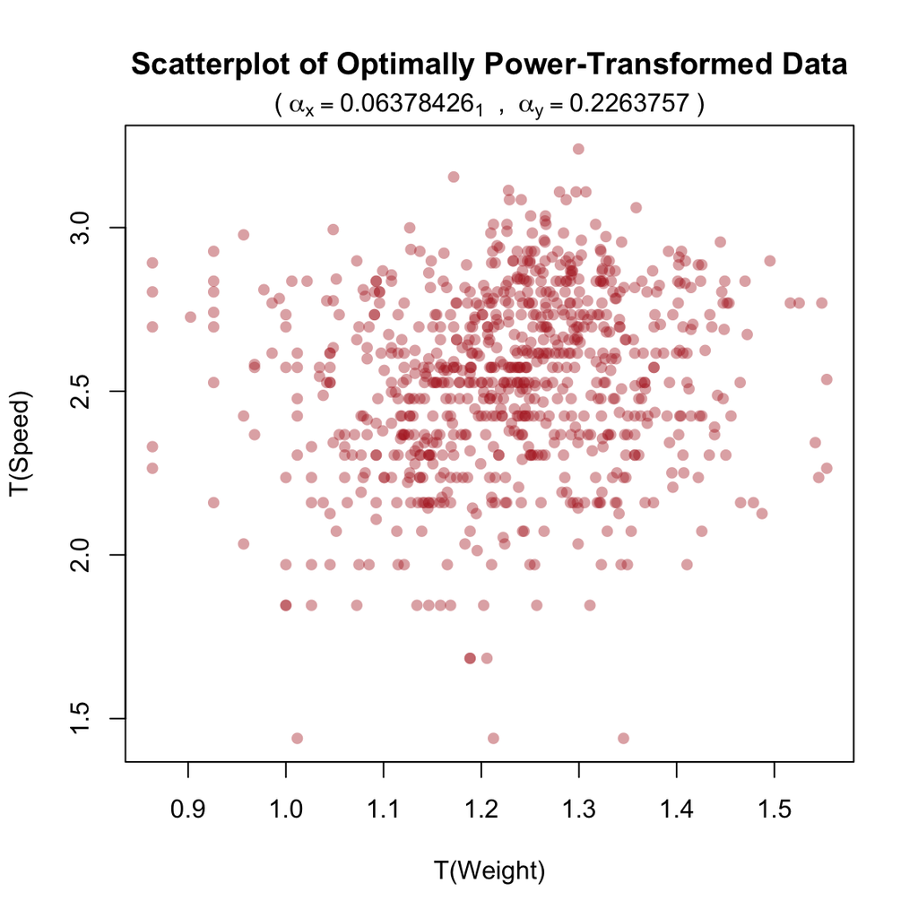

```r
plot(x = powerfun(poke$weight_kg, alpha = min3$par[1]), y = powerfun(poke$speed,
    alpha = min3$par[2]), main = "Scatterplot of Optimally Power-Transformed Data",
    xlab = "T(Weight)", ylab = "T(Speed)", pch = 16, col = adjustcolor(col = "firebrick",
        alpha = 0.4))
mtext(text = bquote("(" ~ alpha[x] == .(min3$par)[1] ~ " , " ~ alpha[y] ==
    .(min3$par[2]) ~ ")"), side = 3)
```

Notice the “optimal correlation” is 0.1431949, which is not so different from the one we found (0.14163987) using Bump Rule #2 – and our transformations are much more easily interpreted. In general, although we can always find an optimal power transformation algorithmically (like we did above), the ladder heuristc tends to work pretty well.